```python
__author__ = 'Knut Olsen <kolsen@noao.edu>, Robert Nikutta <robert.nikutta@noirlab.edu>' # single string; emails in <>
__version__ = '20210114' # yyyymmdd; version datestamp of this notebook
__datasets__ = ['des_dr1']  # enter used datasets by hand
__keywords__ = ['dwarf galaxy','Fornax','Healpix map','plot:cmd']
```

# Exploring DES DR1

*Knut Olsen, Robert Nikutta & the Astro Data Lab Team*

# Imports and setup

```python
# std lib
from copy import copy
import warnings
warnings.filterwarnings('ignore')

# 3rd party
import numpy as np
import healpy as hp
from astropy.utils.data import download_file
import pylab as plt
import matplotlib
%matplotlib inline

# Datalab and related imports
from dl import queryClient as qc
```

# Make an object density map

By using `GROUP BY`, we can aggregate in specified bins. In this next query, the `GROUP BY` clause tells the database to aggregate the results by the values in the `nest4096` column, and return the average RA and Dec of objects in those groups, as well as the `nest4096` value itself and the count of the number of objects in the group.

The long selection block using `wavg_spread_model_i` is defined in the DES DR1 release paper as the set of criteria so select point-like sources.

```python
# select point sources with g-r<0.75, g>19.5, and gerr<0.2
desquery = """
SELECT avg(ra) as ra0,
       avg(dec) as dec0,
       nest4096,
       count(nest4096) as nb
FROM des_dr1.main
WHERE wavg_spread_model_i>(-90)
AND mag_auto_g<90
AND (mag_auto_g-mag_auto_r)<0.75
AND mag_auto_g>19.5
AND magerr_auto_g<0.2
AND (((wavg_spread_model_i + 3*wavg_spreaderr_model_i)<0.005 AND
      (wavg_spread_model_i + wavg_spreaderr_model_i)<0.003 AND
      (wavg_spread_model_i - wavg_spreaderr_model_i)<0.003
     ) OR (
      (wavg_spread_model_i + 3*wavg_spreaderr_model_i)>=0.005 AND
      (wavg_spread_model_i + wavg_spreaderr_model_i)<0.003 AND
      (wavg_spread_model_i - wavg_spreaderr_model_i)<0.003
     ) OR (
      (wavg_spread_model_i + 3*wavg_spreaderr_model_i)<0.005 AND
      (wavg_spread_model_i + wavg_spreaderr_model_i)>=0.003 AND
      (wavg_spread_model_i - wavg_spreaderr_model_i)<0.003
     ) OR (
      (wavg_spread_model_i + 3*wavg_spreaderr_model_i)<0.005 AND
      (wavg_spread_model_i + wavg_spreaderr_model_i)<0.003 AND
      (wavg_spread_model_i - wavg_spreaderr_model_i)>=0.003
     )
    )
GROUP BY nest4096
"""
```

```python
%%time
# This query should take 3-6 minutes
df_desdensity = qc.query(sql=desquery,fmt='pandas',timeout=600)
```

```
CPU times: user 6.63 s, sys: 2.24 s, total: 8.87 s
Wall time: 1min 54s
```

```python
df_desdensity
```

|  | ra0 | dec0 | nest4096 | nb |
| --- | --- | --- | --- | --- |
| 0 | 44.980361 | 0.047813 | 11 | 1 |
| 1 | 44.998287 | 0.066371 | 15 | 1 |
| 2 | 45.036813 | 0.098710 | 30 | 1 |
| 3 | 44.939822 | 0.059274 | 34 | 1 |
| 4 | 44.952358 | 0.086211 | 44 | 2 |
| ... | ... | ... | ... | ... |
| 7972669 | 316.271362 | -1.258900 | 201315612 | 2 |
| 7972670 | 316.225781 | -1.265289 | 201315621 | 1 |
| 7972671 | 316.237055 | -1.260298 | 201315632 | 1 |
| 7972672 | 316.310203 | -1.258636 | 201315648 | 1 |
| 7972673 | 316.397344 | -1.191259 | 201315669 | 2 |

7972674 rows × 4 columns

```python
print(np.sum(df_desdensity['nb'])) # print total counts
```

```
11531107
```

### Making the Healpix map

A Healpix map is simply a one-dimensional array with number of elements set by the NSIDE parameter, which is the number of times the base Healpixels are split. We can visualize it as a map using the `healpy` library.

```python
tmap = np.zeros(hp.nside2npix(4096))
```

### Function for plotting on the sphere

```python
def plot_sphere(m,fig=None,rot=(20,-30,0),cmap='viridis',half_sky=True,notext=True,log=True,coord='C',min_=None,max_=None,mark=None):
    m_ = copy(m)
    m_[m_<=0] = hp.UNSEEN
    if log is True:
        MIN = m_[m_>0].min()
#        m_[m_<=0] = 1*MIN
        m_ = np.log10(m_)
    if fig is None:
        fig = plt.figure(figsize=(15,15))
    hp.orthview(m_,nest=True,min=min_,max=max_,fig=1,rot=rot,cmap=cmap,coord=coord,half_sky=half_sky,norm='linear',notext=notext)
    hp.graticule(c='w')

    if mark is not None:
        ra, dec = mark
        phi = ra
        theta = dec
        foo=hp.projplot(phi,theta,marker='o',ms=30,mec='w',mfc='none',mew=3,coord='C',lonlat=True,markersize=10,direct=False)

    return fig
```

### Populating the Healpix map

```python
tmap[df_desdensity['nest4096']] = df_desdensity['nb']
```

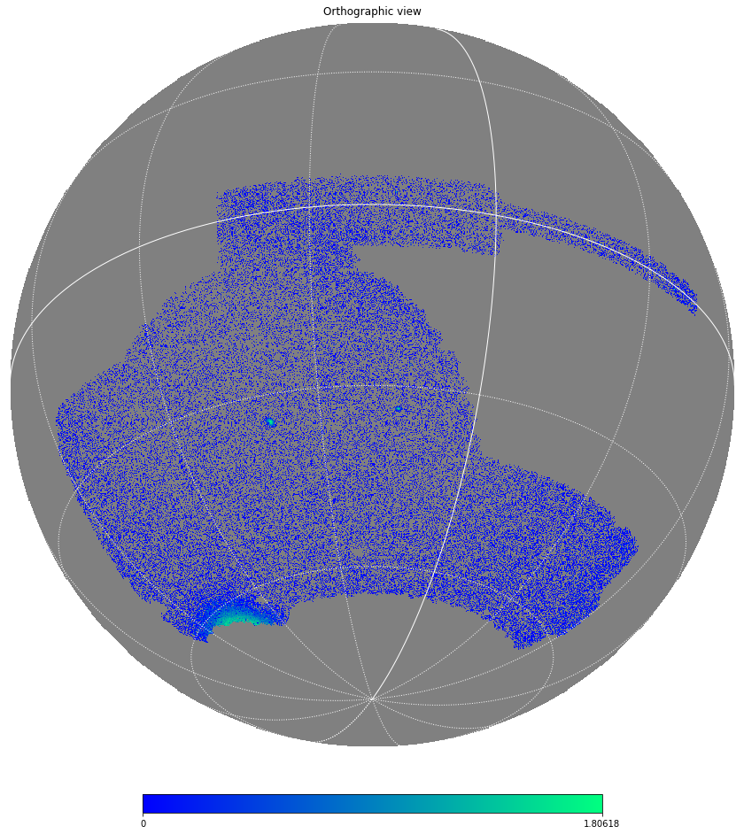

```python
fig = plot_sphere(tmap,cmap='winter')
```

An NSIDE 4096 healpix map is pretty high resolution (~1 arcmin). If we downgrade the resolution to NSIDE = 256, it helps bring out low surface brightness features.

```python
map256 = hp.ud_grade(tmap,256,order_in='NESTED',order_out='NESTED')
```

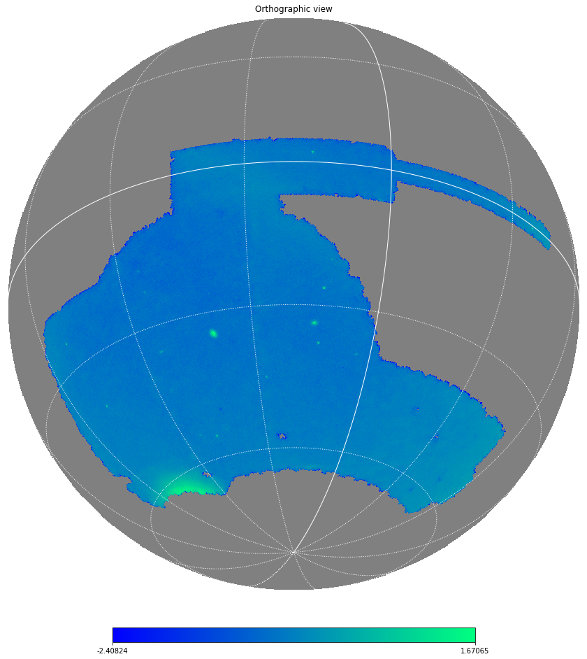

```python
fig = plot_sphere(map256,cmap='winter',max_=None)
```

### Plot again with an upper cutoff to bring out the inhomogeneity better

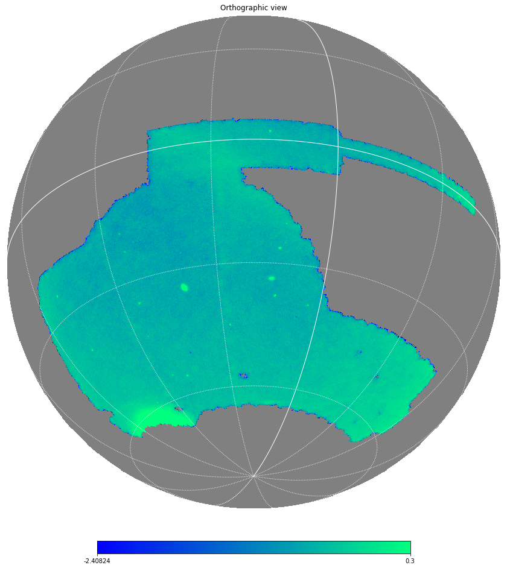

```python
fig = plot_sphere(map256,cmap='winter',max_=0.3)
```

# Load teff map created by Knut earlier, and use as weight map

```python
teff = hp.read_map('des_teff_g.fits',nest=True)
```

Let's downsample it to nest256 as well

```python
teff256 = hp.ud_grade(teff,256,order_in='NESTED',order_out='NESTED')
```

### Now we can plot the teff map

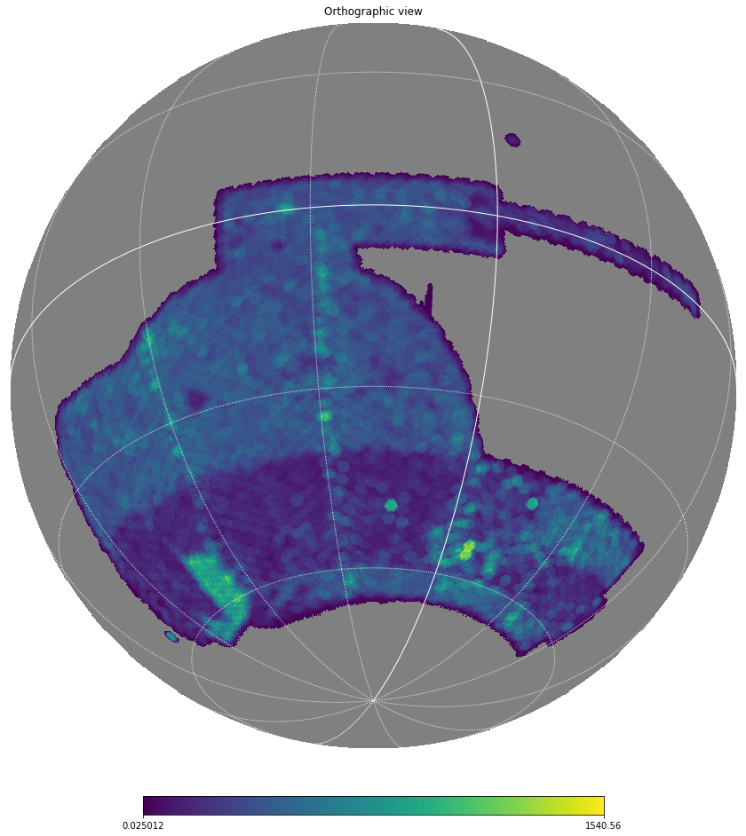

```python
fig = plot_sphere(teff256,log=False,cmap='viridis')
```

### Plot the weighted map

Some of the structure introduced by survey depth and instrumental effects are corrected (though not perfectly).

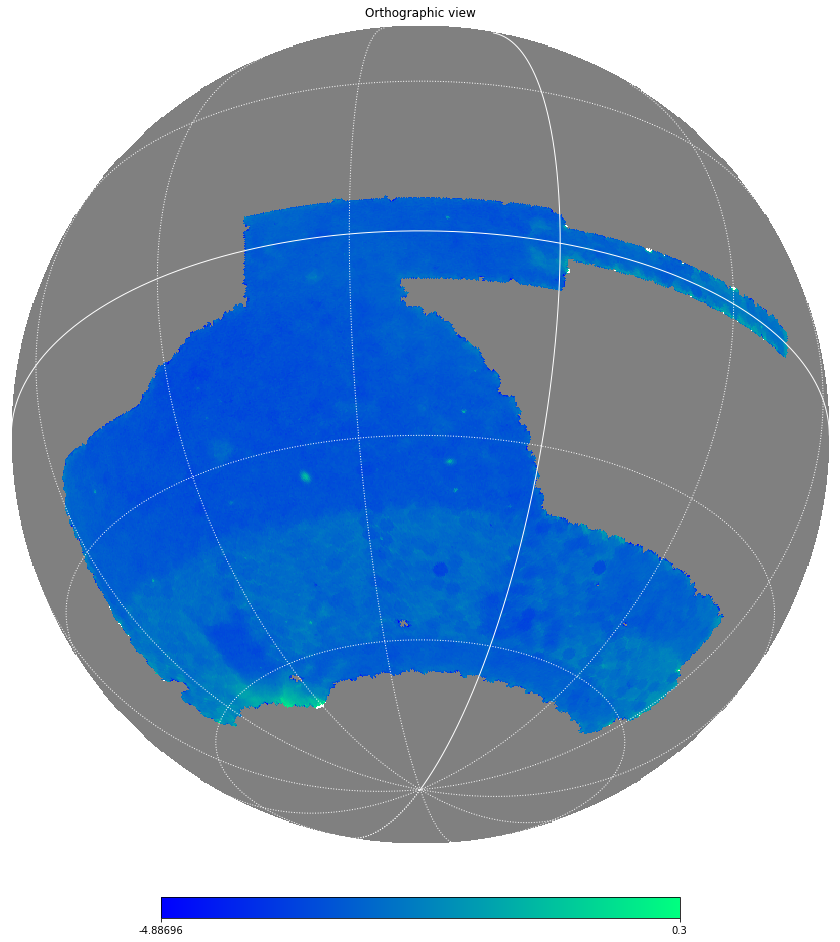

```python
fig = plot_sphere(map256/teff256,log=True,cmap='winter',max_=0.3)
```

### Mark one prominent Dwarf Galaxy -- Fornax

We do this manually here, but could also for instance run a peak finder (we have a notebook on that in Data Lab).

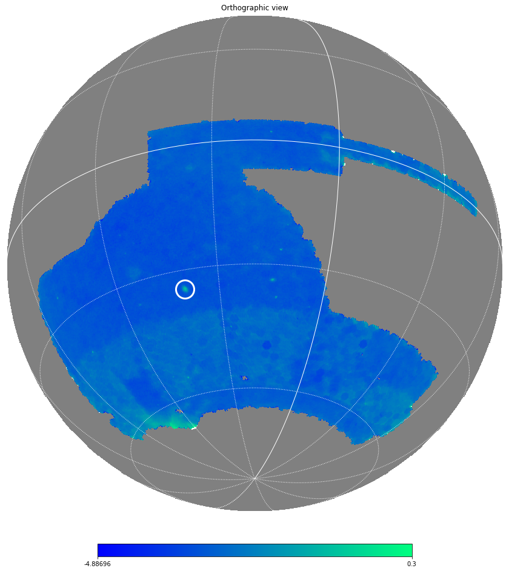

```python
ra, dec = 39.9970833, -34.4491667 # coordinates of Fornax Dwarf
fig = plot_sphere(map256/teff256,log=True,cmap='winter',max_=0.3,mark=(ra, dec))
```

# Get an image of the Dwarf Galaxy

We can either use a SIA service to identify suitable images for cutouts, or go the ~lazy~ convenient route calling Legacy Sky Viewer

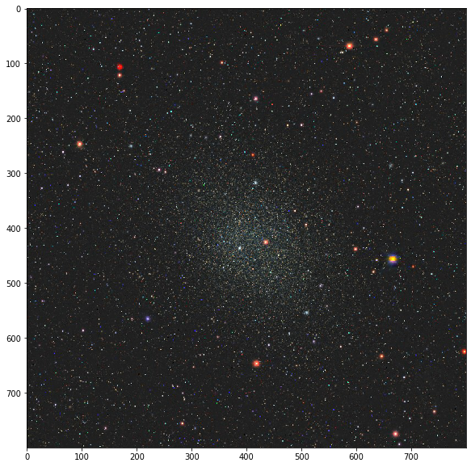

```python
cutout = "https://www.legacysurvey.org/viewer/cutout.jpg?ra=%f&dec=%f&layer=des-dr1&zoom=9&size=800" % (ra,dec)
img = plt.imread(download_file(cutout,cache=True,show_progress=False,timeout=120))

fig = plt.figure(figsize=(10,10))
plt.imshow(img)
```

# Query for photometry to make a CMD

```python
# spatial query around the position, with cuts on mags, magerr (SNR)
query = """
SELECT mag_auto_g as g, mag_auto_r as r
FROM des_dr1.main
WHERE q3c_radial_query(ra,dec,%f,%f,%f)
AND mag_auto_g between 9 and 25
AND mag_auto_r between 9 and 25
AND magerr_auto_g < 0.2
AND magerr_auto_r < 0.2
""" % (ra,dec,0.3)

print(query)
```

```
SELECT mag_auto_g as g, mag_auto_r as r
FROM des_dr1.main
WHERE q3c_radial_query(ra,dec,39.997083,-34.449167,0.300000)
AND mag_auto_g between 9 and 25
AND mag_auto_r between 9 and 25
AND magerr_auto_g < 0.2
AND magerr_auto_r < 0.2
```

```python
%%time
# this query should take just a second or two
df = qc.query(sql=query,fmt='pandas')
df.shape
```

```
CPU times: user 106 ms, sys: 10.7 ms, total: 117 ms
Wall time: 534 ms
```

```
(122667, 2)
```

### Plot a CMD

```python
def plot_cmd(x,y,title='',xlim=(-1,2),ylim=(25.5,16)):
    fig = plt.figure(figsize=(8,8))
    ax = fig.add_subplot(111)
    ax.scatter(x,y,marker='.',s=0.3, alpha=0.5)
    ax.set_xlabel('g - r')
    ax.set_ylabel('g')
    ax.set_xlim(xlim)
    ax.set_ylim(ylim)
    ax.set_title(title)
```

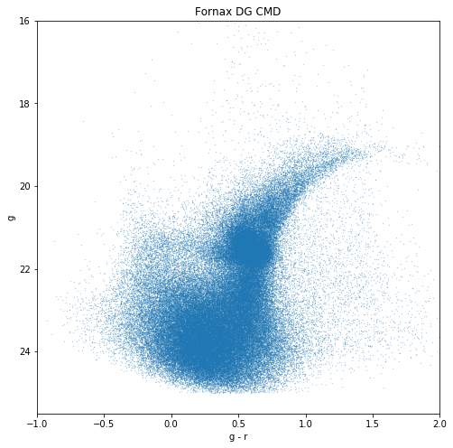

```python
plot_cmd(df['g']-df['r'],df['g'],title='Fornax DG CMD')
```